# Unidade 1: Construção de Funções em R

Computação em Estatística II

Autor

Prof. Donald M. Pianto

Data de Publicação

28 de agosto de 2025

## Introdução

Na aula de revisão, vimos como usar `dplyr` para filtrar dados e `if`/`else` para controlar a lógica do nosso código. Vimos também que copiar e colar o mesmo código várias vezes é ineficiente e propenso a erros.

A solução para este problema é a **criação de funções**. Uma função é uma ferramenta reutilizável que encapsula uma série de operações.

### Por que criar funções?

1. **Evitar a repetição:** Se você se vir a copiar e colar o mesmo bloco de código mais de duas vezes, é um sinal de que precisa de uma função.
2. **Tornar o código mais legível:** Funções bem nomeadas tornam a sua análise mais fácil de ler e entender.
3. **Reduzir erros:** Ao centralizar a lógica num único local, a depuração e a manutenção do código tornam-se muito mais simples.

### A Anatomia de uma Função

A estrutura básica de uma função em R é a seguinte:

```r
nome_da_funcao <- function(argumento1, argumento2) {
  # Corpo da função: o que ela faz
  resultado <- argumento1 + argumento2

  # Valor de retorno: o que a função devolve
  return(resultado)
}
```

Hoje, vamos construir duas funções passo a passo para explorar cada um destes componentes.

```r
# Carregar pacotes que usaremos na aula
library(tidyverse)
library(gapminder)
```

## Exemplo 1: Uma Função Simples (`maxminratio`)

Vamos começar com um exemplo simples para calcular a razão entre o valor máximo e mínimo de um vetor numérico.

### Passo 1: A Função Básica

Uma função de uma linha é a forma mais simples de começar.

```r
maxminratio <- function(x) {
  max(x) / min(x)
}

# Testando a função
meu_vetor <- c(1, 2, 5, 10)
maxminratio(meu_vetor)
```

```
[1] 10
```

Podemos até usar esta função com `apply` para aplicá-la a cada coluna de uma matriz.

```r
minha_matriz <- matrix(1:12, ncol = 3)
apply(minha_matriz, 2, maxminratio)
```

```
[1] 4.000000 1.600000 1.333333
```

### Passo 2: Introduzindo um Problema (Valores `NA`)

O que acontece se o nosso vetor de entrada tiver um valor ausente (`NA`)?

```r
vetor_com_na <- c(1, 2, 5, 10, NA)
maxminratio(vetor_com_na)
```

```
[1] NA
```

A função retorna `NA`. Isto pode ser o comportamento desejado, mas muitas vezes queremos que a função ignore os `NA`s.

### Passo 3: Adicionando um Argumento com Valor Padrão

Podemos tornar a nossa função mais robusta e flexível, permitindo que o usuário decida como lidar com os `NA`s. Fazemos isso adicionando um argumento com um valor padrão.

```r
maxminratio <- function(x, na.rm = FALSE) {
  max(x, na.rm = na.rm) / min(x, na.rm = na.rm)
}
```

- **`na.rm = FALSE`**: Este é o **valor padrão**. Se o usuário não especificar nada, a função comportar-se-á como antes.
- **`na.rm = na.rm`**: Passamos o valor do nosso argumento `na.rm` para as funções `max()` e `min()`.

Agora, a função é muito mais útil:

```r
# Comportamento padrão (ainda retorna NA)
maxminratio(vetor_com_na)
```

```
[1] NA
```

```r
# Novo comportamento (ignora o NA)
maxminratio(vetor_com_na, na.rm = TRUE)
```

```
[1] 10
```

## Exemplo 2: Uma Função de Análise de Dados

Agora, vamos construir uma função mais completa, inspirada numa das nossas tarefas de casa. O objetivo é criar uma ferramenta que analise os dados do `gapminder` para um país específico.

### Passo 1: O Esqueleto da Função

Começamos por definir o nome da função e os seus argumentos. Queremos que o usuário possa especificar um `pais` e, opcionalmente, um vetor de `anos`.

```r
analisar_pais <- function(pais, anos = unique(gapminder$year)) {
  # O corpo da função ainda está vazio
}
```

### Passo 2: Lógica Principal e Retorno

O núcleo da nossa função será um filtro `dplyr`. No final, queremos que a função **retorne** o `data.frame` filtrado.

```r
analisar_pais <- function(pais, anos = unique(gapminder$year)) {

  dados_filtrados <- gapminder |>
    filter(country == pais, year %in% anos)

  return(dados_filtrados)
}

# Testando
dados_brasil <- analisar_pais(pais = "Brazil", anos = c(1997, 2002, 2007))
print(dados_brasil)
```

```
# A tibble: 3 × 6
  country continent  year lifeExp       pop gdpPercap
  <fct>   <fct>     <int>   <dbl>     <int>     <dbl>
1 Brazil  Americas   1997    69.4 168546719     7958.
2 Brazil  Americas   2002    71.0 179914212     8131.
3 Brazil  Americas   2007    72.4 190010647     9066.
```

### Passo 3: Tratamento de Erros (Validação de Entradas)

O que acontece se um usuário digita um nome de país que não existe?

```r
# analisar_pais(pais = "Brasil") # Isto daria um resultado vazio, o que é confuso.
```

Uma função robusta deve verificar as suas entradas e falhar de forma controlada e informativa. Usamos `if` e `stop()` para isso.

```r
analisar_pais <- function(pais, anos = unique(gapminder$year)) {

  # 1. Verificar se o país existe
  if (!pais %in% unique(gapminder$country)) {
    stop("País não encontrado. O nome do país precisa estar em inglês!")
  }

  # 2. Verificar se todos os anos existem
  if (!all(anos %in% unique(gapminder$year))) {
    stop("Ano não disponível.")
  }

  # Lógica principal (como antes)
  dados_filtrados <- gapminder |>
    filter(country == pais, year %in% anos)

  return(dados_filtrados)
}

# Testando o tratamento de erros
try(analisar_pais(pais = "Brasil"), silent = TRUE)
try(analisar_pais(pais = "Brazil", anos = c(2007, 2008)), silent = TRUE)
```

### Passo 4: Saídas Múltiplas e Condicionais

Uma função não precisa de se limitar a retornar um único objeto. Ela pode ter “efeitos colaterais”, como imprimir mensagens ou criar gráficos.

Vamos adicionar duas funcionalidades: 1. Imprimir sempre uma mensagem sobre a população em 2007. 2. Criar um gráfico da expectativa de vida, mas apenas se o usuário o solicitar.

```r
analisar_pais <- function(pais,
                          anos = unique(gapminder$year),
                          gerar_grafico = TRUE,
                          ...) { # Adicionamos o argumento ...

  # Validação de Entradas (como antes)
  if (!pais %in% unique(gapminder$country)) {
    stop("País não encontrado. O nome do país precisa estar em inglês!")
  }
  if (!all(anos %in% unique(gapminder$year))) {
    stop("Ano não disponível.")
  }

  # Lógica Principal
  dados_filtrados <- gapminder |>
    filter(country == pais, year %in% anos)

  # --- Saídas ---

  # 1. Mensagem no console (efeito colateral)
  pop_pais_2007 <- gapminder$pop[gapminder$country == pais & gapminder$year == 2007]
  continente_pais <- unique(gapminder$continent[gapminder$country == pais])
  pop_continente_2007 <- sum(as.numeric(gapminder$pop[gapminder$continent == continente_pais & gapminder$year == 2007]))
  percentual_pop <- (pop_pais_2007 / pop_continente_2007) * 100

  cat(
    paste0("Em 2007, ", pais, " respondia por ",
           round(percentual_pop, 2), "% da população do continente.\n")
  )

  # 2. Gráfico condicional (efeito colateral)
  if (gerar_grafico) {
    plot_vida <- ggplot(dados_filtrados, aes(x = year, y = lifeExp)) +
      geom_line(color = "blue", linewidth = 1) +
      geom_point(color = "red", size = 3) +
      labs(
        title = paste("Expectativa de Vida em", pais),
        x = "Ano",
        y = "Expectativa de Vida"
      ) +
      theme_minimal() +
      labs(...) # Passamos o argumento ... para o labs()

    print(plot_vida)
  }

  # 3. Valor de retorno
  return(dados_filtrados)
}
```

### Passo 5: Usando o Argumento `...` (Avançado)

O argumento `...` (dots) é especial: ele captura quaisquer argumentos que não correspondam aos argumentos nomeados da função. Isso é útil para passar opções para outras funções dentro da sua.

Na nossa função, passamos o `...` para `labs()`. Isso permite que o usuário personalize os rótulos do gráfico diretamente!

```
Em 2007, Argentina respondia por 4.48% da população do continente.
```

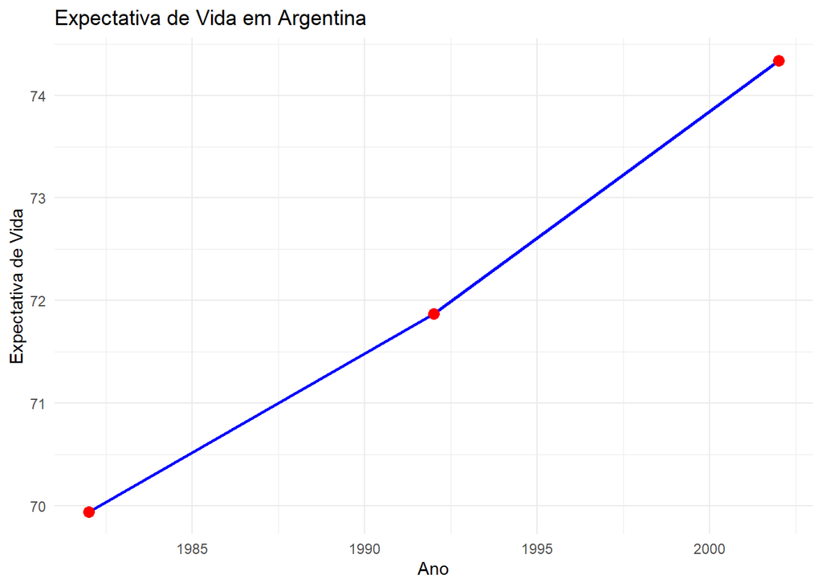

```
# A tibble: 3 × 6
  country   continent  year lifeExp      pop gdpPercap
  <fct>     <fct>     <int>   <dbl>    <int>     <dbl>
1 Argentina Americas   1982    69.9 29341374     8998.
2 Argentina Americas   1992    71.9 33958947     9308.
3 Argentina Americas   2002    74.3 38331121     8798.
```

```r
# Chamada padrão
analisar_pais("Argentina", anos = c(1982, 1992, 2002))
```

```
Em 2007, Argentina respondia por 4.48% da população do continente.
```

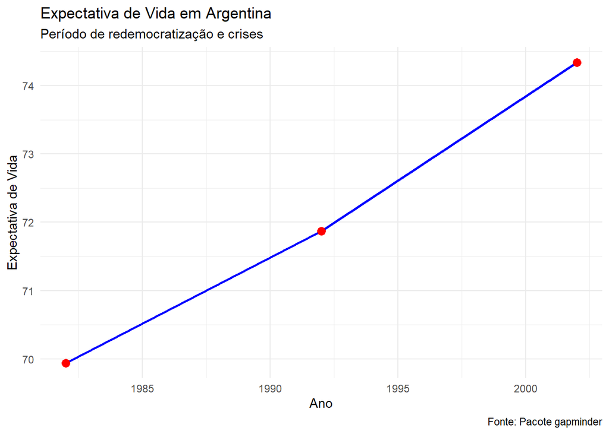

```
# A tibble: 3 × 6
  country   continent  year lifeExp      pop gdpPercap
  <fct>     <fct>     <int>   <dbl>    <int>     <dbl>
1 Argentina Americas   1982    69.9 29341374     8998.
2 Argentina Americas   1992    71.9 33958947     9308.
3 Argentina Americas   2002    74.3 38331121     8798.
```

```r
# Chamada personalizada com o argumento ...
analisar_pais("Argentina", anos = c(1982, 1992, 2002),
              subtitle = "Período de redemocratização e crises",
              caption = "Fonte: Pacote gapminder")
```

## Exercício de Aula: Coeficiente de Variação

Agora é a sua vez. Vamos criar uma função para uma medida estatística comum.

O **coeficiente de variação (CV)** é uma medida de dispersão relativa, definida como o desvio padrão dividido pela média: `CV = sd(x) / mean(x)`.

**Sua Tarefa:**

1. **Parte A: Função Básica**
   - Crie uma função chamada `coef_variacao` que recebe um único argumento, um vetor numérico `x`.
   - O corpo da função deve calcular o desvio padrão de `x`, a média de `x`, e retornar o resultado da divisão do primeiro pelo segundo.
2. **Parte B: Função Robusta**
   - Modifique a sua função `coef_variacao` para que ela possa lidar com vetores que contêm valores `NA`.
   - Assim como no nosso exemplo `maxminratio`, adicione um argumento `na.rm` com o valor padrão `FALSE`.
   - Passe este argumento para as funções `sd()` e `mean()` dentro do corpo da sua função.
3. **Teste a sua função** com os vetores `vetor_a` e `vetor_b` fornecidos abaixo.

```r
vetor_a <- c(10, 12, 15, 18, 20)
vetor_b <- c(10, 12, 15, 18, 20, NA)
```

```r
# Escreva a sua função aqui


# Teste a sua função aqui
# coef_variacao(vetor_a)
# coef_variacao(vetor_b)
# coef_variacao(vetor_b, na.rm = TRUE)
```